# Multiscale network complementarity

The topological and functional complementarity of the compiled networks and randomisation

Pisanu Ize Buphamalai (CeMM & Max Perutz Lab Vienna)www.cemm.at  
2021-03-25

Disease modules, the hallmark concept for disease gene localization in network medicine, have been extensively studied on the PPI network. In this study, we expanded this concept across scales by incorporating additional databases that were selected to represent the multiscale biological relationships from genotypes to phenotypes. These multiscale network construction from databases of various formats including the bipartite mapping (e.g. the gene-pathway association), the ontology-based semantic similarity measurement (e.g. the Gene Ontology annotation), and correlation-based relationship extracted from quantitative studies such as GTEx expression data. These networks are complementary on different levels.

```r
knitr::opts_chunk$set(echo = FALSE, message = FALSE, warning = FALSE)
library(pacman)
p_load(patchwork, igraph, tidyverse, cowplot, rmarkdown)

# compute different network properties
if(!file.exists("../cache/network_complementarity_topological.RDS")){
  # load required functions
source("../source/network_properties_analysis.R")

} else{
  print("Load precomputed data")
  g_prop_df <- readRDS("../cache/network_complementarity_topological.RDS")
}
```

```
[1] "Load precomputed data"
```

```r
network_details <- read_tsv("../data/network_details.tsv", col_types = 'ccccc')
```

# Network details

```r
paged_table(network_details %>% select(!type))
```

| network | main_type | subtype | source |
| --- | --- | --- | --- |
| GOBP | Other | Biological Process | GO |
| GOMF | Other | Molecular Function | GO |
| HP | Other | Human Phenotype | HPO |
| MP | Other | Mammalian Phenotype | MPO |
| co-essential | Other | Co-essentiality | Kim et. al. |
| ppi | Other | Protein-protein interaction | HIPPIE |
| reactome_copathway | Other | Co-Pathway Membership | Reactome |
| coex_GEJ | Co-expression | Gastroesophageal junction | GTEx |
| coex_TST | Co-expression | Testis | GTEx |
| coex_FIB | Co-expression | Fibroblast cell line | GTEx |

[output cut: 35 more lines]

# Topological complementarity

Social bias: many networks were constructed based on curation from literatures. The social bias of a network is assessed by the Spearman’s correlation coefficient between the network degree of a gene and the number of publications mentioning the gene. The number of publications was queried using the INDRA python module (http://www.indra.bio, accessed on 12 April 2019)

```r
g_prop_df %>% select(network, property, value) %>% paged_table()
```

| network | property | value |
| --- | --- | --- |
| co-essential | Number of nodes | 3.483000e+03 |
| coex_ADS | Number of nodes | 7.737000e+03 |
| coex_ADV | Number of nodes | 9.690000e+03 |
| coex_ARG | Number of nodes | 1.038800e+04 |
| coex_ATA | Number of nodes | 9.574000e+03 |
| coex_ATC | Number of nodes | 1.120900e+04 |
| coex_ATT | Number of nodes | 1.037900e+04 |
| coex_BRB | Number of nodes | 6.699000e+03 |
| coex_BRC | Number of nodes | 1.159200e+04 |
| coex_BRO | Number of nodes | 1.177100e+04 |

[output cut: 305 more lines]

The plot below summarises the table properties.

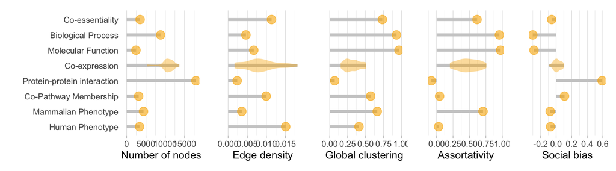

```r
# create a list of  plots to patch together
plot = list()
for(prop in unique(g_prop_df$property)){
  plot[[prop]] = g_prop_df  %>%
    arrange(group) %>% filter(property == prop) %>%
    ggplot( aes(x=group, y=as.numeric(value))) +
    geom_segment( aes(x=group, xend=group, y=0, yend=value), color="grey80", size=1.5) +
    geom_violin(fill="#F8B100", alpha = 0.4, color = NA) +
    geom_point( aes(color=alphaval), size=4, alpha=0.6) +
    theme_light() +
    coord_flip() +
    theme(
      panel.grid.major.y = element_blank(),
      panel.border = element_blank(),
      axis.ticks.y = element_blank(),
     # axis.text.y = element_blank(),
    ) +
    guides(color = F)+
    xlab("") +
    scale_color_manual(values = c("#F8B100",NA)) +
    ylab(prop)

  # scale y log for some properties (n edges)
  if(prop %in% c("Number of edges")){
    plot[[prop]] = plot[[prop]] + scale_y_log10()
  }

  # for the first plot, allows axis label
  if(!prop %in% c("Number of nodes")){
    plot[[prop]] = plot[[prop]] +  theme(axis.text.y = element_blank())
  }

}

plot_combine = plot$`Number of nodes` + plot$`Edge density` + plot$`Global clustering` + plot$Assortativity + plot$`Social bias` + plot_layout(nrow = 1)

# uncomment to save the plot as pdf
#ggsave("../Figs/network_properties_characterisation.pdf", plot_combine, height = 2.5, width = 9)

suppressWarnings(print(plot_combine))
```